# APAlyzer

# 7 Plot the APA results

The APA comparison can be plotted using either violin plot or CDF curves. Let’s use the previous 3’UTR APA and IPA comparison output as an example, first build the plotting data frame:

```r
test_3UTRmuti$APA="3'UTR"
test_IPAmuti$APA="IPA"
dfplot=rbind(test_3UTRmuti[,c('RUD','APA')],test_IPAmuti[,c('RUD','APA')])
```

We can then plot violin and CDF curves using *ggplot2*:

```r
library(ggplot2)
```

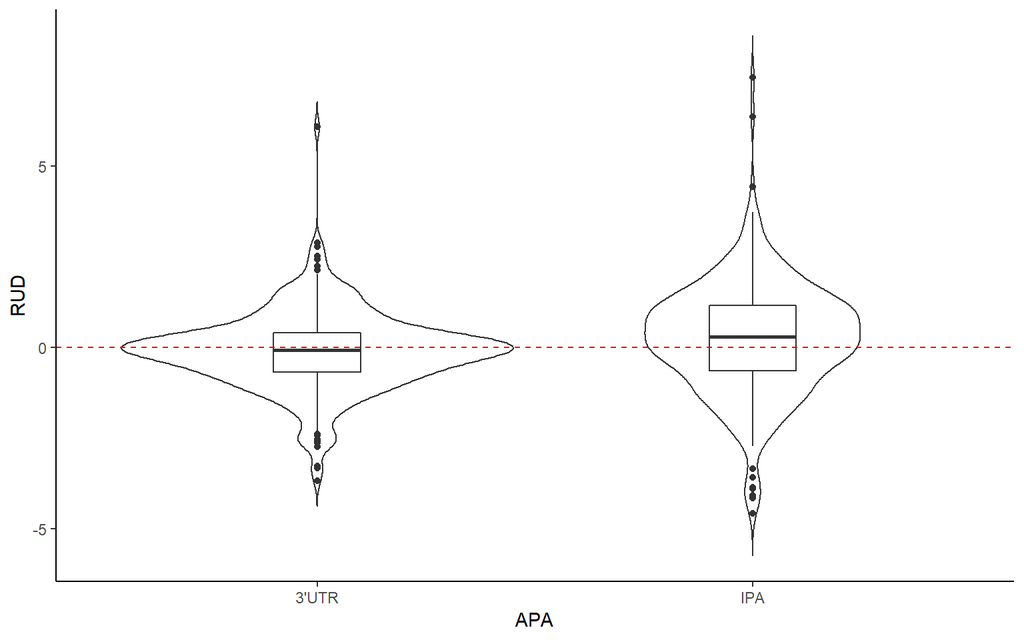

```r
###violin
ggplot(dfplot, aes(x = APA, y = RUD)) + geom_violin(trim = FALSE) + geom_boxplot(width = 0.2)+ geom_hline(yintercept=0, linetype="dashed", color = "red")
```

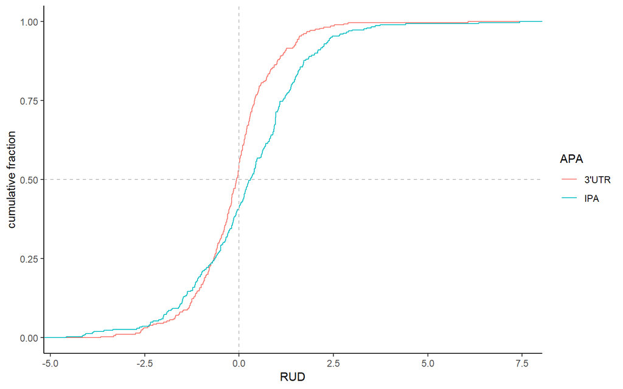

```r
###CDF
ggplot(dfplot, aes( x = RUD, color = APA)) + stat_ecdf(geom = "step") +ylab("cumulative fraction")+ geom_vline(xintercept=0, linetype="dashed", color = "gray")+ geom_hline(yintercept=0.5, linetype="dashed", color = "gray")
```

# 8 Analyze expression of coding genes

APA is frequently involved in gene expression regulation. To compare the gene expression versus APA in different samples. Our package also provide a simple function to assess the expression profile using RNA-seq samples.

## 8.1 Build reference CDS regions using

```r
library("GenomicFeatures")
library("org.Mm.eg.db")
txdb <- makeTxDbFromUCSC(genome="mm9", tablename="refGene")
seqlevels(txdb) <-"chr19"
IDDB <- org.Mm.eg.db
CDSdbraw=REFCDS(txdb,IDDB)
```

## 8.2 Extract reads count and calculte TPM for each gene

```r
DFGENEraw=GENEXP_CDS(CDSdbraw, flsall, Strandtype="forward")
```

# 9 FAQs

## 9.1 How to generate the bamfile list for analysis?

The bam file list containing both bam file name and path of the file. Let’s say all the bamfiles are stored in bamdir, then bam file lists can be obtained through:

```r
flsall <- dir(bamdir,".bam")
flsall<-paste0(bamdir,flsall)
names(flsall)<-dir(bamdir,".bam")
```

## 9.2 Why am I getting error when I try to get txdb using makeTxDbFromUCSC?

Some time you’ll get error when you are using old version of Bioconductor. You can either upgrade your Bioconductor, load the genome annotation using GTF, or load the prebuild genome anotation using ‘.R.DB’ file, e.g., mm9.refGene.R.DB.